# Sanskar Bista - Reproduce Research Course Project

12/18/2020

## Assignment Instructions

1. Code for reading in the dataset and/or processing the data
2. Histogram of the total number of steps taken each day
3. Mean and median number of steps taken each day
4. Time series plot of the average number of steps taken
5. The 5-minute interval that, on average, contains the maximum number of steps
6. Code to describe and show a strategy for imputing missing data
7. Histogram of the total number of steps taken each day after missing values are imputed
8. Panel plot comparing the average number of steps taken per 5-minute interval across weekdays and weekends
9. All of the R code needed to reproduce the results (numbers, plots, etc.) in the report

##Step 1 ##Code for reading the dataset

```r
activity <- read.csv("activity.csv")

#Data exploration
dim(activity)
```

```
## [1] 17568     3
```

```r
names(activity)
```

```
## [1] "steps"    "date"     "interval"
```

```r
head(activity)
```

```
##   steps       date interval
## 1    NA 2012-10-01        0
## 2    NA 2012-10-01        5
## 3    NA 2012-10-01       10
## 4    NA 2012-10-01       15
## 5    NA 2012-10-01       20
## 6    NA 2012-10-01       25
```

```r
str(activity)
```

```
## 'data.frame':    17568 obs. of  3 variables:
##  $ steps   : int  NA NA NA NA NA NA NA NA NA NA ...
##  $ date    : chr  "2012-10-01" "2012-10-01" "2012-10-01" "2012-10-01" ...
##  $ interval: int  0 5 10 15 20 25 30 35 40 45 ...
```

##Step 2 ##Histogram of the total number of steps taken each day

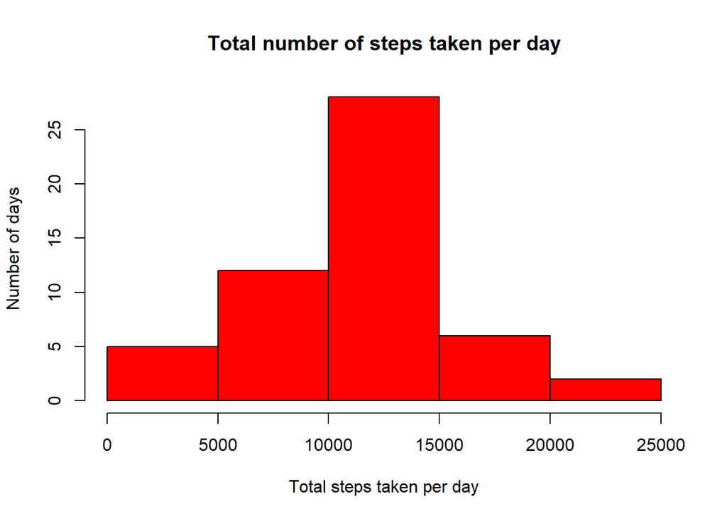

```r
totalsteps <- aggregate(steps ~ date, activity, sum)


hist(totalsteps$steps, main = "Total number of steps taken per day", xlab = "Total steps taken per day", ylab = "Number of days", col = "red")
```

```r
dev.copy(png, file = "Plot1.png", height = 480, width = 480)
```

```r
dev.off()
```

```r
raw_mean <- mean(totalsteps$steps)
raw_median <- median(totalsteps$steps)
```

##Step 4 ##Time Series plot of the average nmber of steps taken

[figure not shown]

```r
totalsteps <- aggregate(steps ~ interval, activity, mean)

plot(totalsteps$interval, totalsteps$steps, type = "l", xlab = "Date", ylab = "Mean steps taken daily", main = "Mean Steps Taken Daily by Date")
```

```r
dev.copy(png, file = "plot2.png", height = 480, width = 480)
```

```r
dev.off()
```

##Step 5 ##Finding the 5-minute interval that, on average, contains the max amount of steps

```r
totalsteps[which.max(totalsteps[,2]),1]
```

```
## [1] 835
```

##Step 6 ##Code for describing and imputing data Optimal strategies to deal with imputing missing variables is mean/mode value substitution

```r
missingValues <- is.na(activity[,1])

m <- mean(totalsteps$steps)

activity1 <- activity
activity1[missingValues,1] <- m
head(activity1)
```

```
##     steps       date interval
## 1 37.3826 2012-10-01        0
## 2 37.3826 2012-10-01        5
## 3 37.3826 2012-10-01       10
## 4 37.3826 2012-10-01       15
## 5 37.3826 2012-10-01       20
## 6 37.3826 2012-10-01       25
```

##Step 7 ##Histogram of total number of steps taken after the missing values have been imputed

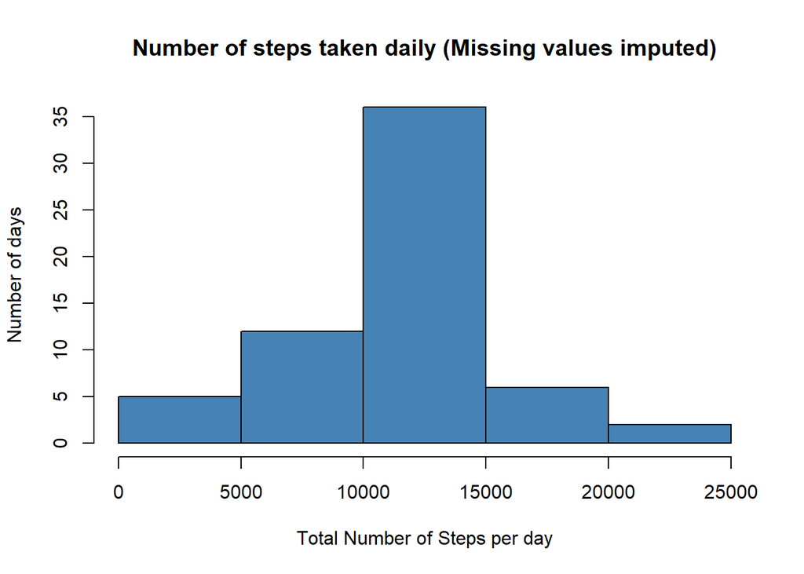

```r
#plotting the new histogram
TotalSteps <- aggregate(steps~date, activity1, sum)
hist(TotalSteps$steps, xlab = "Total Number of Steps per day", ylab = "Number of days", main = "Number of steps taken daily (Missing values imputed)", col = "steelblue")
```

```r
dev.copy(png, file = "Plot3.png", height = 480, width = 480)
```

```r
dev.off()
```

##Step 8 ##Panel plot comparing the average number of steps taken per 5-minute interval across weekdays and weekends

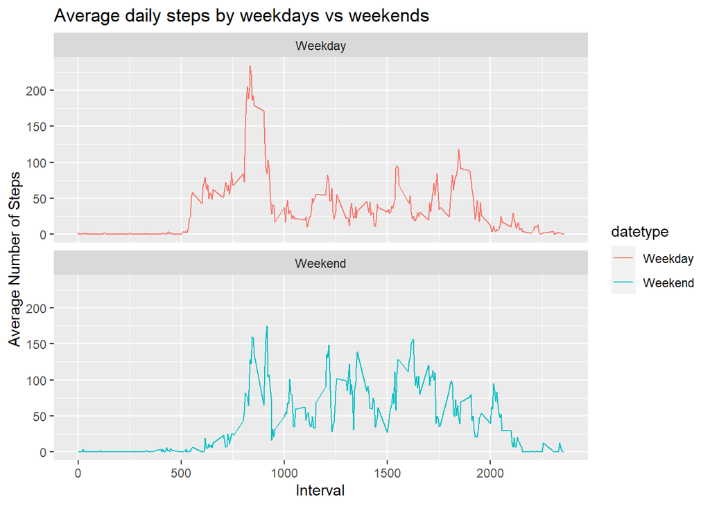

```r
# creating the factors
activity$date <- as.Date(strptime(activity$date, format="%Y-%m-%d"))
activity$datetype <- sapply(activity$date, function(x) {
  if (weekdays(x) == "Saturday" | weekdays(x) == "Sunday")
  {y <- "Weekend"} else
  {y <- "Weekday"}
  y
})

#producing the panel plot
library(ggplot2)
ActbyDayT <- aggregate(steps~interval + datetype, activity, mean, na.rm = T)
g <- ggplot(ActbyDayT, aes(x=interval, y = steps, color = datetype)) + geom_line() + labs(title = "Average daily steps by weekdays vs weekends", x = "Interval", y = "Average Number of Steps") + facet_wrap(~datetype, ncol = 1, nrow = 2)
print(g)
```

```r
dev.copy(png, file = "plot4.png", height = 480, width = 480)
```

```r
dev.off()
```